# diary

Author

Manmohan Pharswan

## Diary Entry 1: Before Assignment 1 10th Feb 2024

Problem: I faced this error while trying to render the quarto document

[figure not shown]

Solution:

So, I was basically not writing the code under code fences and then I when to chatgpt and found out that a code fence looks like this

[figure not shown]

Now I am able to render the code and good to go for Assignment 1.

## Diary Entry 2: 15th Feb

Problem: I encountered this error while reading my dataset which took a long time to be found.

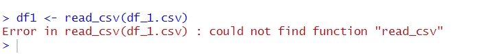

Solution:

Obviously, I went to chatgpt to find the error solution and found out that the I might be missing to install packages but I had done it already so I know this is very lame but a ” ” was missing which I saw just now.

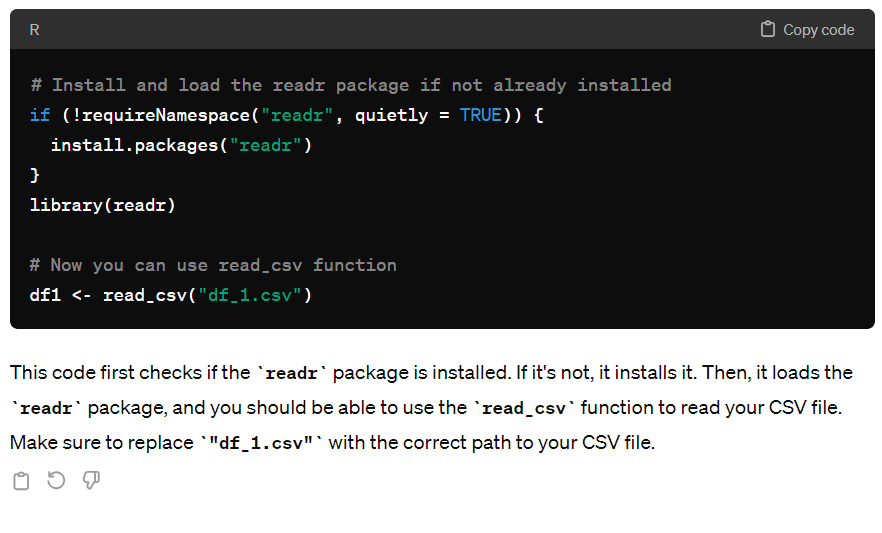

Everything’s back to normal now

## Diary Entry 3: 19th Feb

I am practicing from the lab session:

```r
x<-10
X<-20
x_sum<-x+X


cat("additon of x+X=",x_sum)
```

```
additon of x+X= 30
```

## Diary Entry 4: 24th feb

Lab session practice

```r
set.seed(50)


rolls = replicate(500, sum(sample(1:6, 2, replace = TRUE)))

odd_count = sum(rolls %% 2 != 0)
even_count = sum(rolls %% 2 == 0)


ans = c(Number_Odd = odd_count, Number_Even = even_count)

ans
```

```
 Number_Odd Number_Even
        263         237
```

```r
vec <- 1:6

class(vec)
```

```
[1] "integer"
```

```r
length(vec)
```

```
[1] 6
```

```r
mean(vec)
```

```
[1] 3.5
```

```r
y <- as.numeric(vec)
vec + 5
```

```
[1]  6  7  8  9 10 11
```

```r
b <- rep("yes", 3)
x <- list(12, "John", "Mary", NA, TRUE)

m <- matrix(vec, nrow = 2, ncol = 3)
A <- 1:3
B <- 6:8
m_ab <- cbind(A, B)


x.dat <- data.frame(foo = 1:4, bar = c(TRUE, TRUE, FALSE, FALSE))
rownames(x.dat)
```

```
[1] "1" "2" "3" "4"
```

```r
names(x.dat)
```

```
[1] "foo" "bar"
```

```r
dim(x.dat)
```

```
[1] 4 2
```

```r
mtcars <- read.csv("mtcars.csv")

str(mtcars)
```

```
'data.frame':   32 obs. of  12 variables:
 $ model: chr  "Mazda RX4" "Mazda RX4 Wag" "Datsun 710" "Hornet 4 Drive" ...
 $ mpg  : num  21 21 22.8 21.4 18.7 18.1 14.3 24.4 22.8 19.2 ...
 $ cyl  : int  6 6 4 6 8 6 8 4 4 6 ...
 $ disp : num  160 160 108 258 360 ...
 $ hp   : int  110 110 93 110 175 105 245 62 95 123 ...
 $ drat : num  3.9 3.9 3.85 3.08 3.15 2.76 3.21 3.69 3.92 3.92 ...
 $ wt   : num  2.62 2.88 2.32 3.21 3.44 ...
 $ qsec : num  16.5 17 18.6 19.4 17 ...
 $ vs   : int  0 0 1 1 0 1 0 1 1 1 ...
 $ am   : int  1 1 1 0 0 0 0 0 0 0 ...
 $ gear : int  4 4 4 3 3 3 3 4 4 4 ...
 $ carb : int  4 4 1 1 2 1 4 2 2 4 ...
```

```r
head(mtcars, 10)
```

```
               model  mpg cyl  disp  hp drat    wt  qsec vs am gear carb
1          Mazda RX4 21.0   6 160.0 110 3.90 2.620 16.46  0  1    4    4
2      Mazda RX4 Wag 21.0   6 160.0 110 3.90 2.875 17.02  0  1    4    4
3         Datsun 710 22.8   4 108.0  93 3.85 2.320 18.61  1  1    4    1
4     Hornet 4 Drive 21.4   6 258.0 110 3.08 3.215 19.44  1  0    3    1
5  Hornet Sportabout 18.7   8 360.0 175 3.15 3.440 17.02  0  0    3    2
6            Valiant 18.1   6 225.0 105 2.76 3.460 20.22  1  0    3    1
7         Duster 360 14.3   8 360.0 245 3.21 3.570 15.84  0  0    3    4
8          Merc 240D 24.4   4 146.7  62 3.69 3.190 20.00  1  0    4    2
9           Merc 230 22.8   4 140.8  95 3.92 3.150 22.90  1  0    4    2
10          Merc 280 19.2   6 167.6 123 3.92 3.440 18.30  1  0    4    4
```

```r
cat("Number of rows:", nrow(mtcars), "\n")
```

```
Number of rows: 32
```

```r
cat("Number of columns:", ncol(mtcars), "\n")
```

```
Number of columns: 12
```

```r
mean_mpg <- mean(mtcars$mpg)
median_mpg <- median(mtcars$mpg)
cat("Mean of mpg:", mean_mpg, "\n")
```

```
Mean of mpg: 20.09062
```

```r
cat("Median of mpg:", median_mpg, "\n")
```

```
Median of mpg: 19.2
```

```r
summary(mtcars)
```

```
    model                mpg             cyl             disp
 Length:32          Min.   :10.40   Min.   :4.000   Min.   : 71.1
 Class :character   1st Qu.:15.43   1st Qu.:4.000   1st Qu.:120.8
 Mode  :character   Median :19.20   Median :6.000   Median :196.3
                    Mean   :20.09   Mean   :6.188   Mean   :230.7
                    3rd Qu.:22.80   3rd Qu.:8.000   3rd Qu.:326.0
                    Max.   :33.90   Max.   :8.000   Max.   :472.0
       hp             drat             wt             qsec
 Min.   : 52.0   Min.   :2.760   Min.   :1.513   Min.   :14.50
 1st Qu.: 96.5   1st Qu.:3.080   1st Qu.:2.581   1st Qu.:16.89
 Median :123.0   Median :3.695   Median :3.325   Median :17.71
 Mean   :146.7   Mean   :3.597   Mean   :3.217   Mean   :17.85
 3rd Qu.:180.0   3rd Qu.:3.920   3rd Qu.:3.610   3rd Qu.:18.90
 Max.   :335.0   Max.   :4.930   Max.   :5.424   Max.   :22.90
       vs               am              gear            carb
 Min.   :0.0000   Min.   :0.0000   Min.   :3.000   Min.   :1.000
 1st Qu.:0.0000   1st Qu.:0.0000   1st Qu.:3.000   1st Qu.:2.000
 Median :0.0000   Median :0.0000   Median :4.000   Median :2.000
 Mean   :0.4375   Mean   :0.4062   Mean   :3.688   Mean   :2.812
 3rd Qu.:1.0000   3rd Qu.:1.0000   3rd Qu.:4.000   3rd Qu.:4.000
 Max.   :1.0000   Max.   :1.0000   Max.   :5.000   Max.   :8.000
```

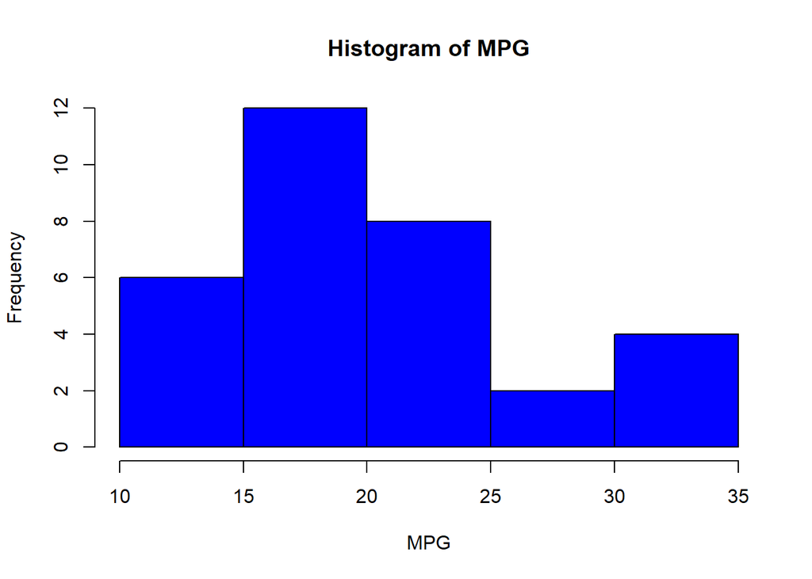

```r
hist(mtcars$mpg, col = "blue", main = "Histogram of MPG", xlab = "MPG")
```

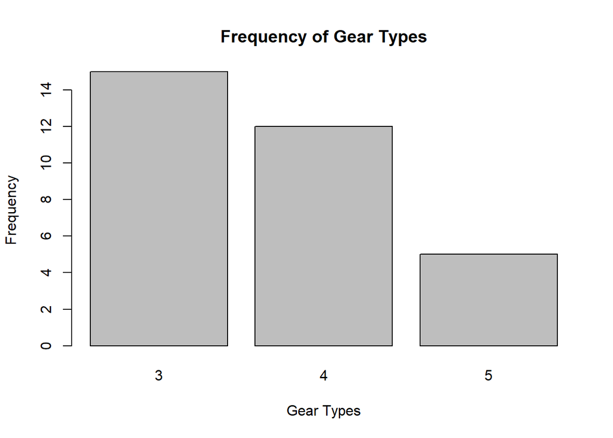

```r
gear_freq <- table(mtcars$gear)
barplot(gear_freq, main = "Frequency of Gear Types", xlab = "Gear Types", ylab = "Frequency")
```

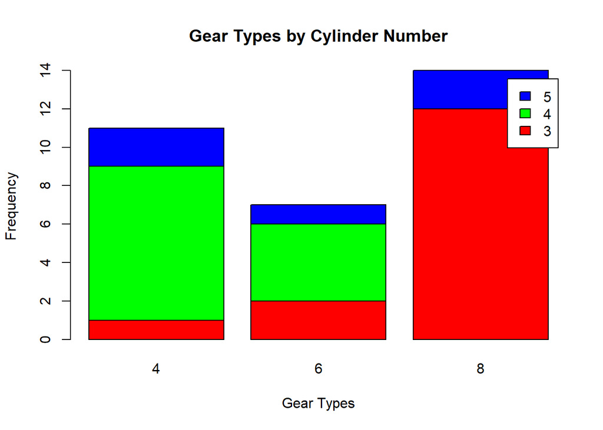

```r
gear_cyl_freq <- table(mtcars$gear, mtcars$cyl)
barplot(gear_cyl_freq, main = "Gear Types by Cylinder Number", xlab = "Gear Types", ylab = "Frequency", col = rainbow(3), legend = rownames(gear_cyl_freq))
```

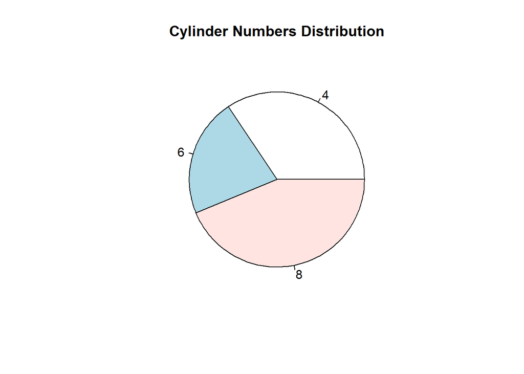

```r
cyl_freq <- table(mtcars$cyl)
pie(cyl_freq, main = "Cylinder Numbers Distribution", labels = names(cyl_freq))
```

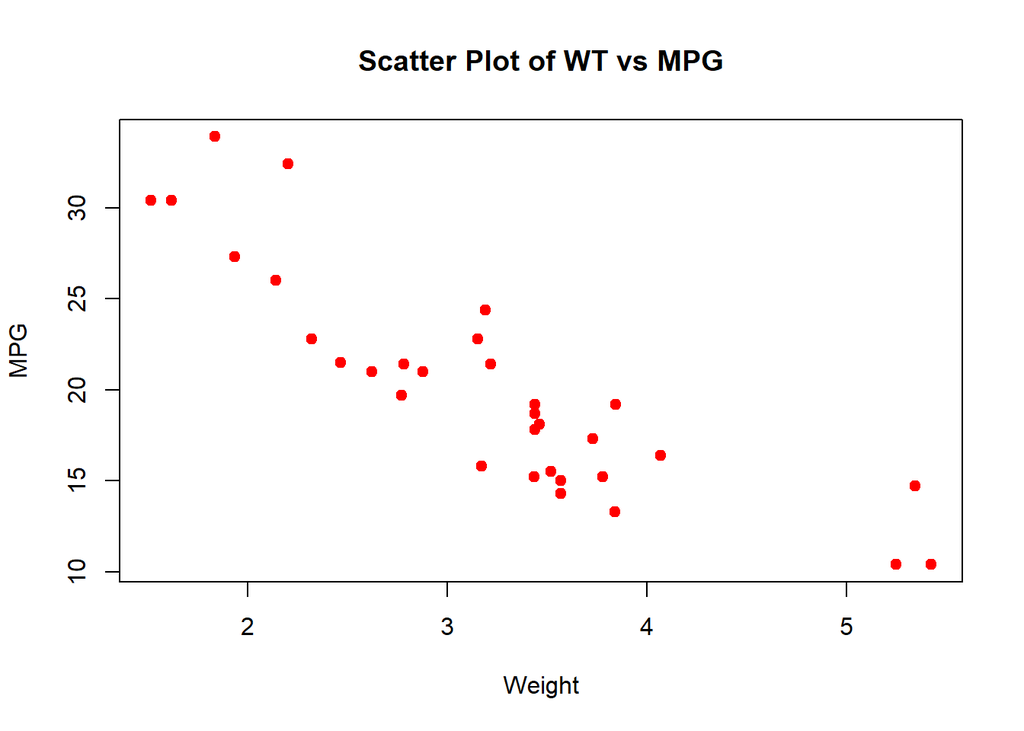

```r
plot(mtcars$wt, mtcars$mpg, main = "Scatter Plot of WT vs MPG", xlab = "Weight", ylab = "MPG", pch = 19, col = "red")
```

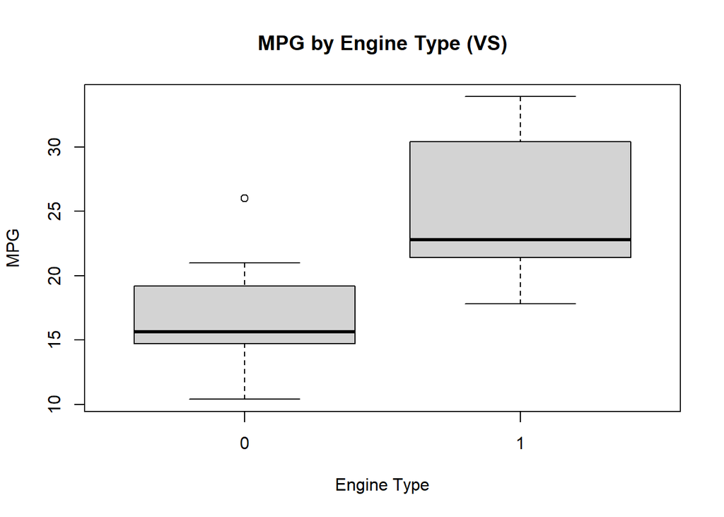

```r
boxplot(mpg ~ vs, data = mtcars, main = "MPG by Engine Type (VS)", xlab = "Engine Type", ylab = "MPG")
```

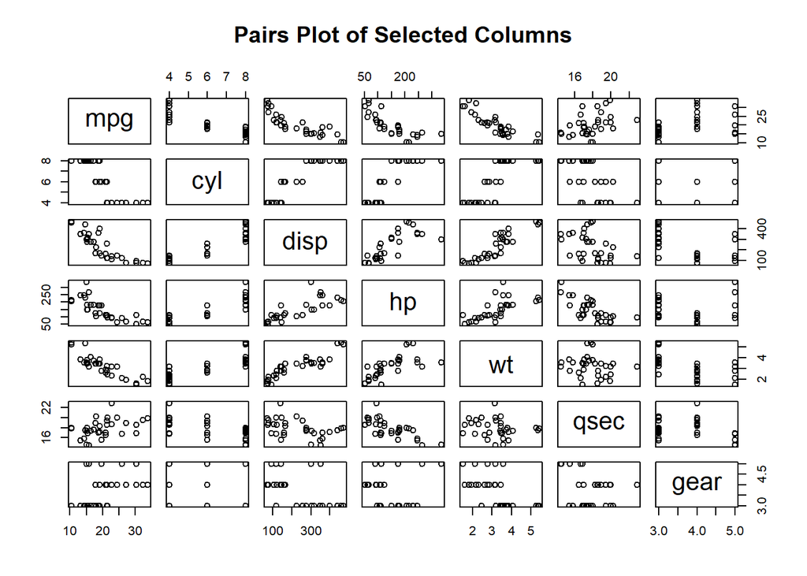

```r
selected_cols_plot <- mtcars[,c("mpg", "cyl", "disp", "hp", "wt", "qsec", "gear")]
pairs(selected_cols_plot, main = "Pairs Plot of Selected Columns")
```

## Diary Entry 5: 25 Feb, Assignment 1 coding

Problem: Faced error saying

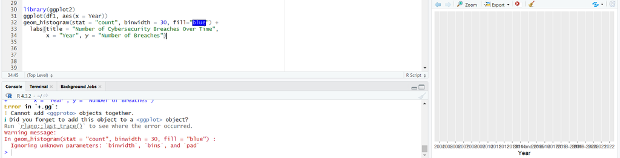

graph is also showing blank.

Solution: I tried to run `rlang::last_trace()` which was written in the console it backtraced but nothing really helped. I googled the error and found this https://forum.posit.co/t/error-cannot-add-ggproto-objects-together-did-you-forget-to-add-this-object-to-a-ggplot-object/11271/2

In the end I found out that we need to remove the arguments to make the code clear on doing that I noticed typo that + was missing. I have added the + sign after ggplot() now let’s see what happens.

Bravo! it worked I am a genius.

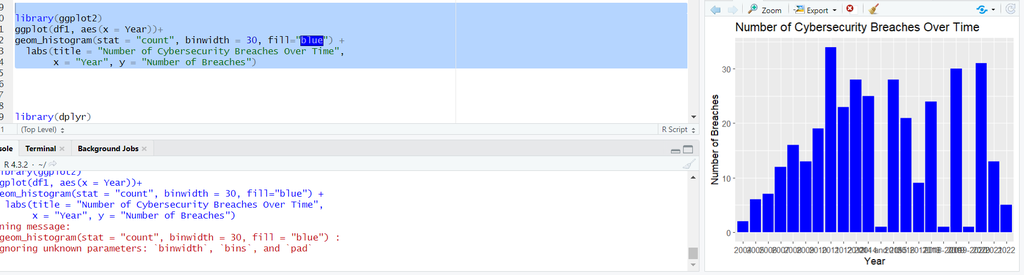

```r
library(dplyr)
library(readr)
df1 <- read_csv("df_1.csv")
df1 <- na.omit(df1) # Remove rows with any missing values

df1$Records <- as.numeric(df1$Records)
summary(df1)
```

```
      ...1          Entity              Year              Records
 Min.   :  0.0   Length:349         Length:349         Min.   :6.700e+03
 1st Qu.: 89.0   Class :character   Class :character   1st Qu.:3.372e+05
 Median :176.0   Mode  :character   Mode  :character   Median :1.850e+06
 Mean   :175.7                                         Mean   :4.394e+07
 3rd Qu.:263.0                                         3rd Qu.:1.850e+07
 Max.   :351.0                                         Max.   :3.000e+09
                                                       NA's   :45
 Organization type     Method
 Length:349         Length:349
 Class :character   Class :character
 Mode  :character   Mode  :character
```

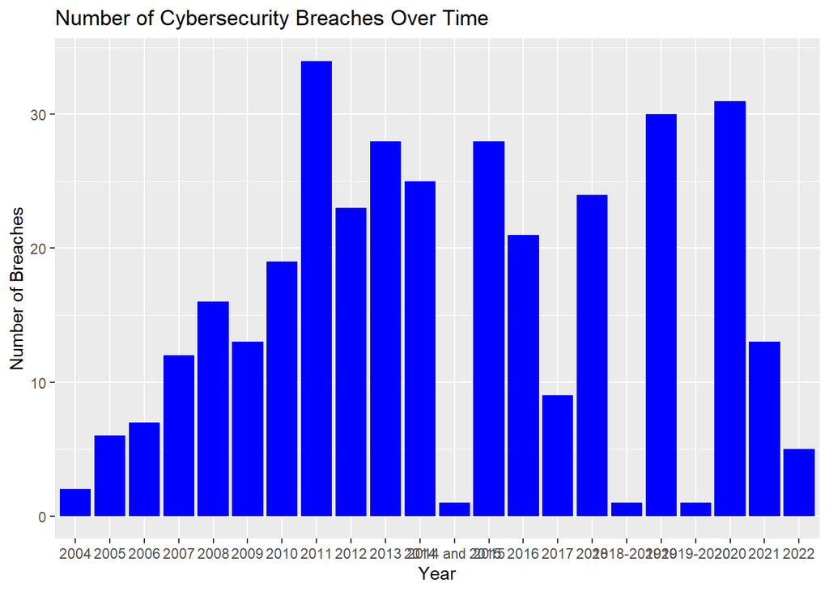

```r
library(dplyr)
# Count breaches by Method
df1_by_Method <- df1 %>%
  group_by(Method) %>%
  summarise(count = n())

# Count breaches by org_type
df1_by_org <- df1 %>%
  group_by(`Organization type`) %>%
  summarise(count = n())



library(ggplot2)
# Plot breaches over time
ggplot(df1, aes(x = Year)) +
  geom_histogram(stat = "count", binwidth = 30, fill="blue") +
  labs(title = "Number of Cybersecurity Breaches Over Time",
       x = "Year", y = "Number of Breaches")
```

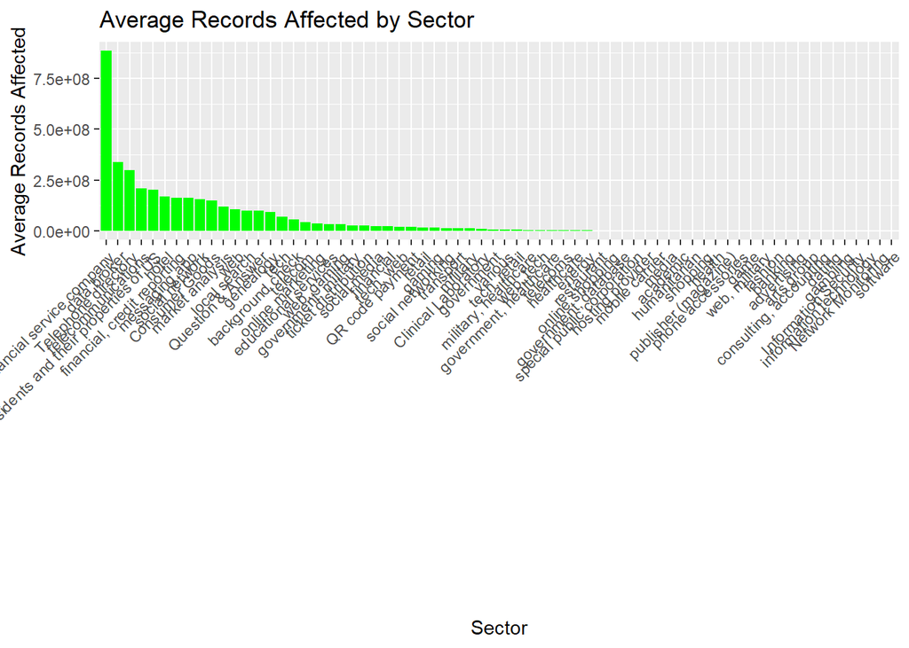

```r
library(dplyr)
#Sector Analysis
# Summarize data by organization type
sector_analysis <- df1 %>%
  group_by(`Organization type`) %>%
  summarise(AverageRecordsAffected = mean(Records, na.rm = TRUE),
            BreachCount = n())


# Sector plotting
ggplot(sector_analysis, aes(x = reorder(`Organization type`, -AverageRecordsAffected), y = AverageRecordsAffected)) +
  geom_bar(stat = "identity", fill="green") +
  theme(axis.text.x = element_text(angle = 45, hjust = 1)) +
  labs(title = "Average Records Affected by Sector",
       x = "Sector",
       y = "Average Records Affected")
```

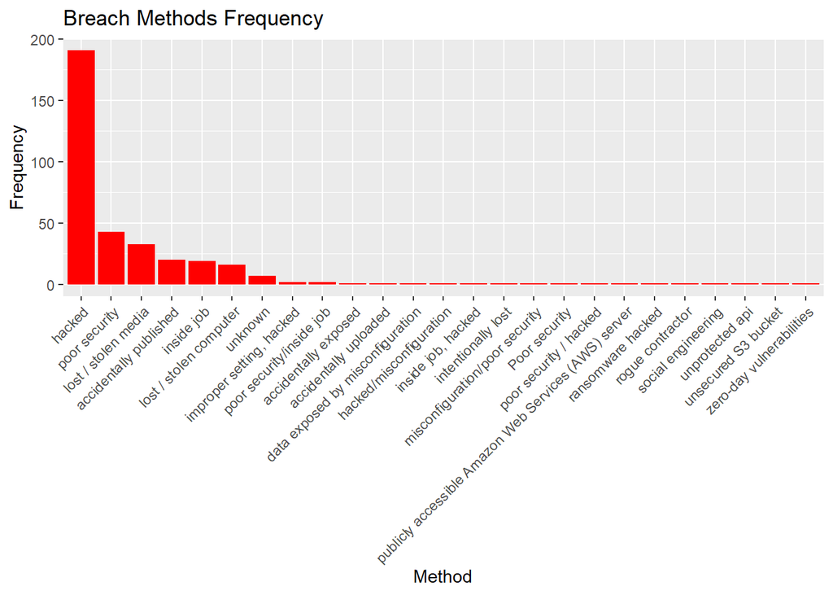

```r
#Method Analysis
method_analysis <- df1 %>%
  group_by(Method) %>%
  summarise(BreachCount = n()) %>%
  arrange(desc(BreachCount))

ggplot(method_analysis, aes(x = reorder(Method, -BreachCount), y = BreachCount)) +
  geom_bar(stat = "identity", fill="red") +
  theme(axis.text.x = element_text(angle = 45, hjust = 1)) +
  labs(title = "Breach Methods Frequency",
       x = "Method",
       y = "Frequency")
```

## Diary Entry 6: 10th March Practicing combing datasets

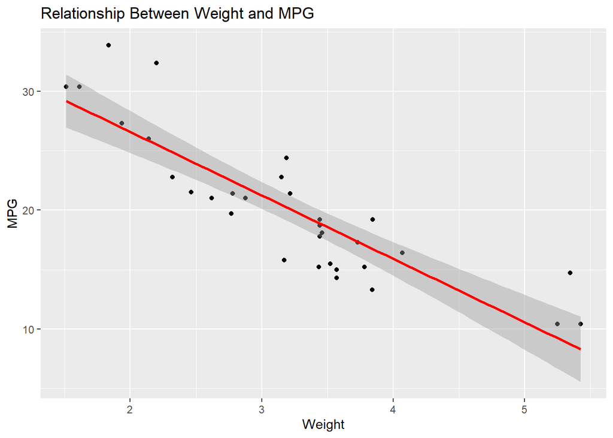

```r
data1 <- data.frame(ID = 1:3, Value = c("A", "B", "C"))
data2 <- data.frame(ID = 2:4, Score = c(90, 85, 75))
combined_data <- inner_join(data1, data2, by = "ID")

# 5. Create relevant visualisations using advanced statistical programming plotting packages
# ----------------------------------------------------------
# Using ggplot2 for visualization
ggplot(mtcars, aes(x = wt, y = mpg)) +
  geom_point() +
  geom_smooth(method = "lm", col = "red") +
  labs(title = "Relationship Between Weight and MPG", x = "Weight", y = "MPG")
```

## Diary Entry 7: 25nd March: Implementing Assignment 3

I implemented that on the code and it worked!

## Diary Entry 8: 26th March

Problem: I faced a problem where when I was implementing the word cloud the output was showing very tiny on the screen.

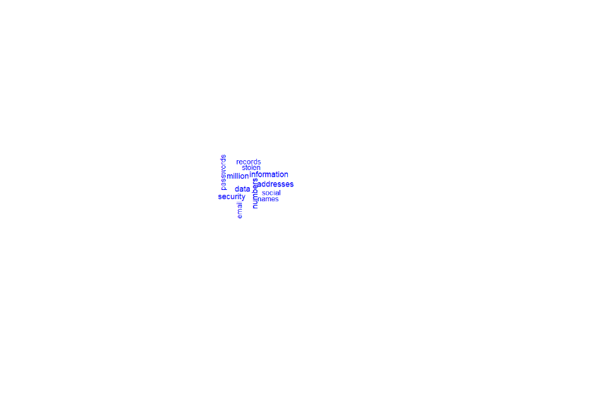

Solution: I then went on to copilot to search for how to increase the font size of the word cloud. because I couldn’t find it on the lab session too. I found this result to use scale parameter.

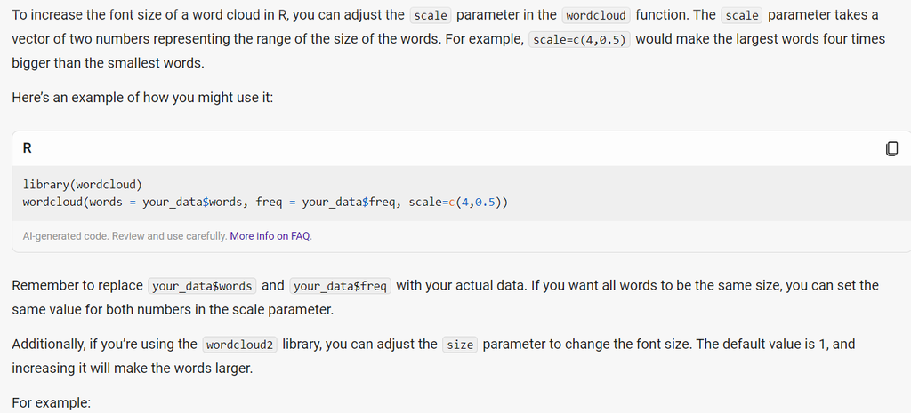

and now the word cloud looks something like this which is more bigger than the last result.

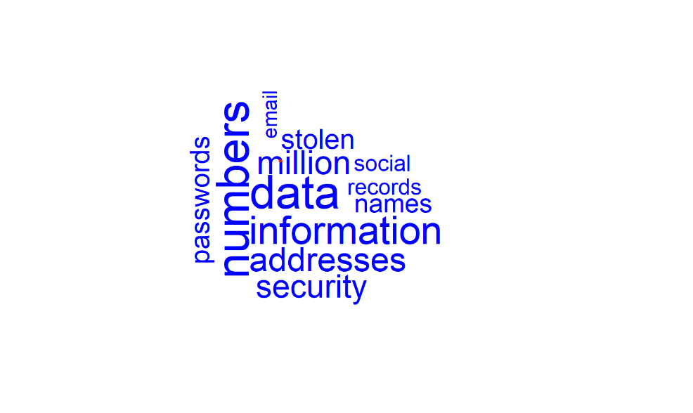

```r
library(dplyr)
library(readr)
library(tm)
library(tidytext)
library(dplyr)
library(readr)
library(tidyr)
library(stringr)
library(tibble)
library(wordcloud)
library(RColorBrewer)
library(mgcv)
library(leaflet)
library(leaflet.extras)
```

# Loaded the datasets

```r
df_1 <- read_csv("df_1.csv")
```

```
──────────────────────────────────────────────────────── Delimiter: "," chr
(5): Entity, Year, Records, Organization type, Method dbl (1): ...1
```

```r
df_2 <- read_csv("df_2.csv")
df_3 <- read_csv("df_3.csv")
df_states <- read_csv("states.csv")
```

## Prepared df_1

```r
df_1_prepared <- df_1 %>%
  rename(NameOfCoveredEntity = Entity, IndividualsAffected = Records, Sector = `Organization type`, BreachMethod = Method) %>%
  mutate(
    Year = as.integer(Year),
    IndividualsAffected = as.numeric(as.character(IndividualsAffected))
  ) %>%
  select(NameOfCoveredEntity, Year, IndividualsAffected, Sector, BreachMethod)
```

## Prepare df_2

```r
df_2_prepared <- df_2 %>%
  rename(NameOfCoveredEntity = Entity, IndividualsAffected = `Records Lost`, Sector = Sector, BreachMethod = `Method of Leak`) %>%
  mutate(
    Year = as.integer(Year),
    IndividualsAffected = as.numeric(as.character(IndividualsAffected))
  ) %>%
  select(NameOfCoveredEntity, Year, IndividualsAffected, Sector, BreachMethod,Story)
```

## Prepare df_3

## Converting ‘Breach Submission Date’ to Year.

```r
df_3$Year <- as.integer(format(as.Date(df_3$`Breach Submission Date`, format="%m/%d/%Y"), "%Y"))

df_3_prepared <- df_3 %>%
  rename(NameOfCoveredEntity = `Name of Covered Entity`, IndividualsAffected = `Individuals Affected`, Sector = `Covered Entity Type`, BreachMethod = `Type of Breach`) %>%
  mutate(IndividualsAffected = as.numeric(as.character(IndividualsAffected))) %>%
  select(NameOfCoveredEntity, Year, IndividualsAffected, Sector, BreachMethod,State)
```

## Combining the datasets

```r
combined_df <- bind_rows(df_1_prepared, df_2_prepared, df_3_prepared)
```

## Filtering out any rows with NA values in key columns for cleaner analysis

```r
combined_df_filtered <- combined_df %>%
  filter(!is.na(IndividualsAffected) & !is.na(Year) & !is.na(Sector) & !is.na(BreachMethod))
```

## Converting IndividualsAffected to numeric, handling non-numeric values gracefully

```r
combined_df_filtered$IndividualsAffected <- as.numeric(as.character(combined_df_filtered$IndividualsAffected))
```

## Checking the structure and head of the combined dataset

```r
str(combined_df_filtered)
```

```
tibble [3,211 × 7] (S3: tbl_df/tbl/data.frame)
 $ NameOfCoveredEntity: chr [1:3211] "21st Century Oncology" "500px" "Accendo Insurance Co." "Adobe Systems Incorporated" ...
 $ Year               : int [1:3211] 2016 2020 2020 2013 2019 2017 2018 2013 2019 2018 ...
 $ IndividualsAffected: num [1:3211] 2.20e+06 1.49e+07 1.75e+05 1.52e+08 7.50e+06 ...
 $ Sector             : chr [1:3211] "healthcare" "social networking" "healthcare" "tech" ...
 $ BreachMethod       : chr [1:3211] "hacked" "hacked" "poor security" "hacked" ...
 $ Story              : chr [1:3211] NA NA NA NA ...
 $ State              : chr [1:3211] NA NA NA NA ...
```

```r
head(combined_df_filtered)
```

```
# A tibble: 6 × 7
  NameOfCoveredEntity   Year IndividualsAffected Sector BreachMethod Story State
  <chr>                <int>               <dbl> <chr>  <chr>        <chr> <chr>
1 21st Century Oncolo…  2016             2200000 healt… hacked       <NA>  <NA>
2 500px                 2020            14870304 socia… hacked       <NA>  <NA>
3 Accendo Insurance C…  2020              175350 healt… poor securi… <NA>  <NA>
4 Adobe Systems Incor…  2013           152000000 tech   hacked       <NA>  <NA>
5 Adobe Inc.            2019             7500000 tech   poor securi… <NA>  <NA>
6 Advocate Medical Gr…  2017             4000000 healt… lost / stol… <NA>  <NA>
```

## Ensuring the response variable is appropriate for modeling (no NAs, non-negative, etc.)

## ‘s()’ allows for smooth (non-linear) effects. Adjust the formula based on your specific analysis needs.

```r
gam_model <- gam(IndividualsAffected ~ s(Year, bs="cs") + Sector + BreachMethod,
                 data = combined_df_filtered, family = nb(), method = "REML")
```

## Summary of the model

```r
summary(gam_model)
```

```
Family: Negative Binomial(0.331)
Link function: log

Formula:
IndividualsAffected ~ s(Year, bs = "cs") + Sector + BreachMethod

Parametric coefficients:
                                                                                                                 Estimate
(Intercept)                                                                                                      14.92285
Sectoracademic                                                                                                   -6.56782
Sectoradvertising                                                                                                -9.27355
SectorApp                                                                                                         2.37729
Sectorbackground check                                                                                           -0.53549
Sectorbanking                                                                                                    -8.99671
SectorBusiness Associate                                                                                         -8.70373
SectorClinical Laboratory                                                                                        -4.21342
SectorConsumer Goods                                                                                             -1.67265
Sectordata broker                                                                                                -0.75982
Sectoreducational services                                                                                       -4.26106
Sectorenergy                                                                                                     -4.16792
SectorEnergy                                                                                                      1.98325
Sectorfashion                                                                                                    -8.77191
Sectorfinancial                                                                                                  -3.54081
SectorFinancial                                                                                                   3.35901
Sectorfinancial service company                                                                                   0.09563
Sectorfinancial, credit reporting                                                                                -1.29786
Sectorgame                                                                                                       -7.76908
Sectorgaming                                                                                                     -3.78982
SectorGaming                                                                                                      3.15598
Sectorgenealogy                                                                                                   0.00000
Sectorgovernment                                                                                                 -4.56414
SectorGovernment                                                                                                  2.51107
Sectorgovernment, database                                                                                       -6.27782
Sectorgovernment, healthcare                                                                                     -5.08296
Sectorgovernment, military                                                                                       -2.53295
Sectorhealth                                                                                                     -7.11107
SectorHealth Plan                                                                                                -8.45351
Sectorhealthcare                                                                                                 -5.41054
SectorHealthcare                                                                                                  1.10022
SectorHealthcare Clearing House                                                                                 -11.41796
```

[output cut: 639 more lines]

```
BreachMethodUnknown                                                                                             ***
BreachMethodunprotected api
BreachMethodunsecured S3 bucket                                                                                 *
---
Signif. codes:  0 '***' 0.001 '**' 0.01 '*' 0.05 '.' 0.1 ' ' 1

Approximate significance of smooth terms:
          edf Ref.df Chi.sq p-value
s(Year) 7.729      9  144.5  <2e-16 ***
---
Signif. codes:  0 '***' 0.001 '**' 0.01 '*' 0.05 '.' 0.1 ' ' 1

Rank: 136/143
R-sq.(adj) =  0.0411   Deviance explained = 68.5%
-REML =  37750  Scale est. = 1         n = 3211
```

## Visualizing effects of the year

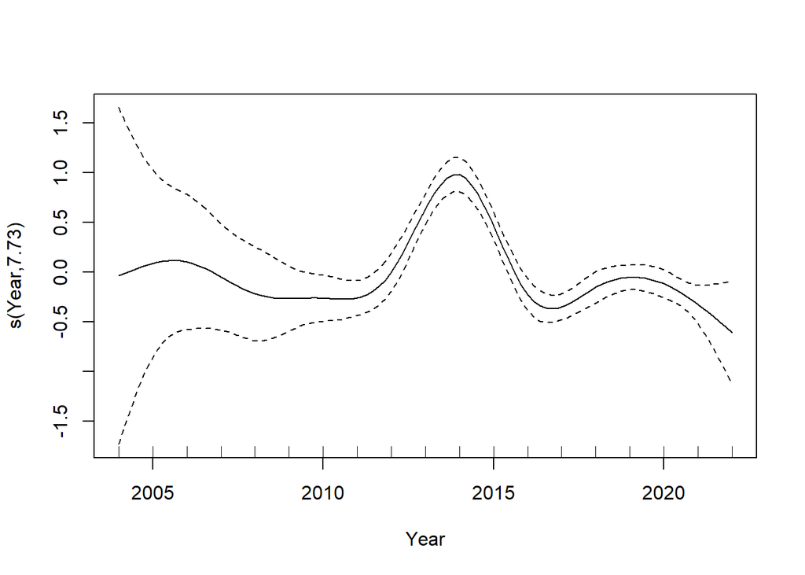

```r
plot(gam_model, page = 1)
```

## Note: ‘bs=“cs”’ uses cubic splines for smoothing. ‘family = nb()’ specifies a negative binomial distribution, suitable for overdispersed count data.

```r
combined_df$Story <- as.character(combined_df$Story)
```

## Created a corpus and clean/preprocess the text

```r
text_corpus <- Corpus(VectorSource(combined_df$Story))
text_corpus_clean <- text_corpus %>%
  tm_map(content_transformer(tolower)) %>%
  tm_map(removePunctuation) %>%
  tm_map(removeNumbers) %>%
  tm_map(removeWords, stopwords("english")) %>%
  tm_map(stripWhitespace)
docs <- sapply(text_corpus_clean$content, as.character)
```

## Created a data frame (tibble) from this vector

```r
docs_df <- tibble(line = 1:length(docs), text = docs)
```

## Transformed the corpus into a tidy text tibble

```r
tidy_text <- tibble(text = sapply(text_corpus_clean, as.character)) %>%
  unnest_tokens(word, text)
```

## identifying frequent words to begin understanding potential themes

```r
word_counts <- tidy_text %>%
  count(word, sort = TRUE) %>%
  filter(n > 32)  # adjust this number based on your dataset
```

## Viewing the most common words to start thinking about potential themes

```r
print(word_counts)
```

```
# A tibble: 13 × 2
   word            n
   <chr>       <int>
 1 <NA>         4553
 2 data           92
 3 numbers        91
 4 information    75
 5 addresses      64
 6 million        63
 7 security       61
 8 stolen         51
 9 passwords      49
10 names          48
11 records        39
12 social         39
13 email          35
```

## Creating the word cloud

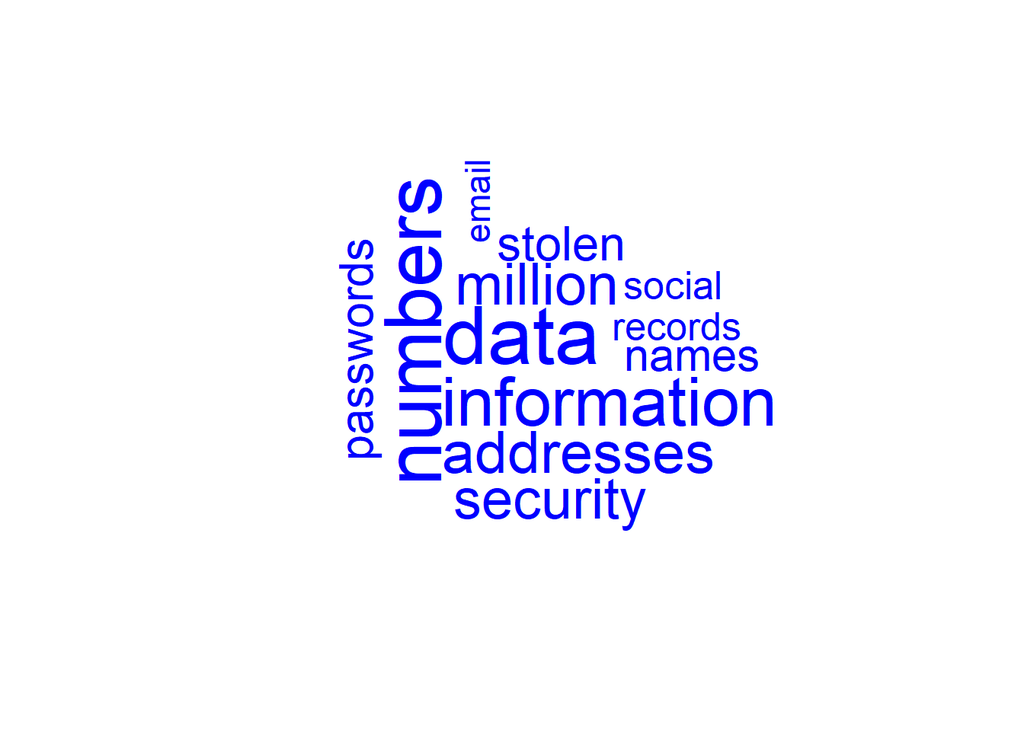

```r
set.seed(123)
wordcloud(words = word_counts$word, freq = word_counts$n,
          min.freq = 1, max.words = 200, random.order = FALSE,
          rot.per = 0.35, colors = c("blue"),scale=c(150,0.3))
```

## SE1: Creating a mermaid diagram to represent the data strems

```
flowchart TD
    LoadDatasets["Load Datasets"] --> PrepareData["Prepare df_1, df_2, df_3"]
    PrepareData --> MergeDatasets["Merge Datasets"]
    MergeDatasets --> FilterCleanData["Filter and Clean Data"]
    FilterCleanData --> GAMAnalysis["Statistical Analysis with GAM"]
    FilterCleanData --> TextPreprocessing["Text Data Preprocessing"]
    TextPreprocessing --> WordCloud["Create Word Cloud"]
    MergeDatasets --> MergeWithStates["Merge with States Dataset"]
    MergeWithStates --> LeafletMap["Plot Leaflet Map"]
```

## SE 2 and 4 Dynamic geographical analysis uing Leaflet represents the numbers of individuals affected in each state.

```r
# Merging on the 'State' column
merged_data <- combined_df %>%
   left_join(df_states, by = c("State" = "state"))


merged_data <- merged_data %>%
  mutate(PopupInfo = paste(State, "<br/>Individuals Affected: ", IndividualsAffected))


aggregated_data <- merged_data %>%
  group_by(State, latitude, longitude) %>%
  summarise(TotalAffected = sum(IndividualsAffected, na.rm = TRUE),
            .groups = 'drop') # Ensure Latitude and Longitude are included for mapping


#Obtained from chatgpt
aggregated_data <- aggregated_data %>%
  mutate(PopupContent = paste("<strong>State:</strong>", State,
                              "<br/><strong>Total Individuals Affected:</strong>", TotalAffected))

leaflet(data = aggregated_data) %>%
  addTiles() %>%
  addCircleMarkers(
    lng = ~longitude,
    lat = ~latitude,
    popup = ~PopupContent,
    clusterOptions = markerClusterOptions()
  ) %>%
  setView(lng = -98.5795, lat = 39.8283, zoom = 4)
```

[interactive chart not shown]

[output not shown]